# Resolución Actividad 3 máster Bioinformática (2025)

Grupo 8

2026-01-21

# Paso 1: Preparación y limpieza de datos

En primer lugar tenemos que cargar las librerías que vamos a utilizar y los datos, seleccionando por una parte únicamente los genes y eliminando aquellas columnas que tienen NAs.

```r
knitr::opts_chunk$set(echo = TRUE)
library(tidyverse)
library(factoextra)
library(pheatmap)
library(gtsummary)
library(gt)
library(gridExtra)
library(broom)

# Generamos una semilla para que los resultados sean reproducibles
set.seed(1234)

# Lectura de los datos
df_simpson <- read.csv("data_simpson.csv", stringsAsFactors = FALSE)

# Se usó list.len = 10 para limitar la información mostrada y no sobrecargar el informe
str(df_simpson, list.len = 10)
```

```
## 'data.frame':    59 obs. of  97 variables:
##  $ X                      : int  1 2 3 4 5 6 7 8 9 10 ...
##  $ orden                  : int  10 2 17 7 8 1 18 54 13 32 ...
##  $ nombre                 : chr  "Barney Gumble" "Homer Simpson" "Apu Nahasapeemapetilon" "Patty Bouvier" ...
##  $ edad_anios             : int  39 40 35 40 40 80 45 80 9 50 ...
##  $ sexo                   : chr  "Masculino" "Masculino" "Masculino" "Femenino" ...
##  $ altura                 : int  175 175 170 170 170 170 180 140 130 175 ...
##  $ peso_kg                : int  130 120 110 95 93 90 100 58 50 90 ...
##  $ imc_kg_m2              : num  42.4 39.2 38.1 32.9 32.2 ...
##  $ ccintura_cm            : int  110 120 95 75 76 95 110 70 65 95 ...
##  $ ccadera_cm             : int  110 130 100 95 95 105 115 85 75 100 ...
##   [list output truncated]
```

```r
col_gen <- df_simpson %>% select(ADCY3:UHMK1) %>% names()

colSums(is.na(df_simpson[, col_gen])) # comprobar el numero de nas
```

```
##    ADCY3     AGRP  ANKRD27     ANO4     BDNF    CADM1    CADM2    CALCR
##        0        0        0        0        0        0        0        0
##     CNR1   CREBRF     DPP9      FTO     GIPR   GPR151    GPR75 KIAA0586
##        0        0        0        0        0        0        0        0
## KIAA1109     KSR2      LEP     LEPR     MC4R    MRAP2     NRP1     NRP2
##        0        0        0        0        0        0        0        0
##    NTRK2    PCSK1    PDE3B     PHIP     POMC    PPARG    ROBO1    SH2B1
##        0        0        0        0        0        0        0        0
##     SIM1    SPARC   TMEM18     UBR2    UHMK1
##        0        0        0        0        0
```

```r
df_clean <- df_simpson %>% # eliminar posibles nas
  drop_na(all_of(col_gen))

# Verificar si alguno de los genes estudiados para expresión génica tienen una varianza cero

## Calcular la varianza
Var_genes <- sapply(df_clean %>% select(ADCY3:UHMK1), var)
# Var_genes # (Opcional mostrarlo para no llenar el reporte)

## Verificar si hay genes con varianzas cero
any(Var_genes == 0)
```

```
## [1] FALSE
```

```r
## Eliminar genes con varianza cero (si los hubiera)
genes_filtrados <- df_clean %>%
  select(ADCY3:UHMK1) %>%
  select(names(Var_genes[Var_genes != 0]))
```

Se realizó una inspección preliminar del conjunto de datos para verificar su estructura utilizando la función str() con el argumento list.len = 10, con el fin de limitar la cantidad de información mostrada y evitar sobrecargar el informe de la actividad. Posteriormente, se evaluó la presencia de valores perdidos (NA) en las variables de expresión génica y se eliminaron los individuos con datos incompletos, confirmándose la ausencia de valores perdidos antes de proceder a los análisis multivariantes. Asimismo, se evaluó la varianza de las variables de expresión génica para descartar la presencia de genes con varianza nula. No se identificaron variables con varianza cero, por lo que todas las variables génicas fueron incluidas en los análisis posteriores. Aunque no se detectaron valores perdidos ni variables con varianza cero en ninguna de las fases del análisis, se decidió incluir el script completo de procesamiento de datos de acuerdo con lo indicado en el enunciado de la actividad

# Paso 2: Normalización

Hecho esto, lo siguiente es normalizar. Para ello primero hacemos un test de Shapiro-Wilk a cada columna y extraemos los p-values que necesitaremos para la actividad.

La prueba de Shapiro-Wilk es un contraste estadístico para determinar si una muestra de datos proviene de una distribución normal, siendo ideal para muestras pequeñas (n<50) y una de las pruebas de normalidad más potentes. Su hipótesis nula ($H_{0}$) es que los datos son normales; si el valor p es bajo (ej. < 0.05), se rechaza $H_{0}$, indicando que no son normales, mientras que un valor p alto sugiere que la distribución es normal, crucial para decidir si usar pruebas paramétricas o no paramétricas.

```r
# Aplicar Shapiro-Wilk a cada columna de genes
shapiro_res <- lapply(df_clean[, col_gen], shapiro.test)

# Extraer p-values numéricos (necesarios para la lógica)
p_values_shapiro <- sapply(shapiro_res, function(x) x$p.value)

# Crear un dataframe para ver resultados
# CAMBIO IMPORTANTE: Formateamos el P_Value para que se vea como texto científico
tabla_normalidad <- data.frame(
  Gen = names(p_values_shapiro),

  # Usamos formatC para forzar notación científica (ej. 1.2e-05)
  # 'format = "e"' activa la notación científica
  # 'digits = 2' muestra 2 decimales después del punto
  P_Value_Texto = formatC(p_values_shapiro, format = "e", digits = 2),

  Es_Normal = p_values_shapiro > 0.05
)

# Muestra cuántos genes cumplen o no el criterio de normalidad
knitr::kable(
  tabla_normalidad,
  row.names = FALSE,
  col.names = c("Gen", "Valor P", "¿Es Normal?"), # Nombres bonitos para la cabecera
  align = "c", # Centrar las columnas
  caption = "Resultados del test de normalidad Shapiro–Wilk por gen"
)
```

Resultados del test de normalidad Shapiro–Wilk por gen

| Gen | Valor P | ¿Es Normal? |
| --- | --- | --- |
| ADCY3 | 1.10e-08 | FALSE |
| AGRP | 1.30e-09 | FALSE |
| ANKRD27 | 6.47e-08 | FALSE |
| ANO4 | 8.04e-10 | FALSE |
| BDNF | 2.81e-11 | FALSE |
| CADM1 | 3.14e-06 | FALSE |
| CADM2 | 8.38e-11 | FALSE |
| CALCR | 8.74e-07 | FALSE |
| CNR1 | 2.49e-07 | FALSE |
| CREBRF | 8.45e-10 | FALSE |
| DPP9 | 4.58e-06 | FALSE |
| FTO | 7.55e-06 | FALSE |
| GIPR | 2.50e-07 | FALSE |
| GPR151 | 1.98e-04 | FALSE |
| GPR75 | 8.69e-08 | FALSE |
| KIAA0586 | 4.65e-06 | FALSE |
| KIAA1109 | 7.75e-05 | FALSE |
| KSR2 | 1.05e-06 | FALSE |
| LEP | 2.11e-09 | FALSE |
| LEPR | 8.93e-08 | FALSE |
| MC4R | 4.51e-05 | FALSE |
| MRAP2 | 1.04e-11 | FALSE |
| NRP1 | 2.59e-06 | FALSE |
| NRP2 | 7.19e-08 | FALSE |
| NTRK2 | 1.01e-08 | FALSE |
| PCSK1 | 2.32e-06 | FALSE |
| PDE3B | 1.35e-09 | FALSE |
| PHIP | 1.20e-07 | FALSE |
| POMC | 3.62e-08 | FALSE |
| PPARG | 3.40e-08 | FALSE |
| ROBO1 | 1.69e-09 | FALSE |
| SH2B1 | 3.65e-06 | FALSE |
| SIM1 | 8.91e-09 | FALSE |
| SPARC | 2.67e-05 | FALSE |
| TMEM18 | 1.15e-06 | FALSE |
| UBR2 | 1.51e-08 | FALSE |
| UHMK1 | 2.67e-07 | FALSE |

## Interpretación de los resultados

La **Tabla 1** detalla los resultados de la prueba de **Shapiro-Wilk** para la expresión relativa de los genes analizados. Esta prueba evalúa la hipótesis nula ($H_0$) de que los datos provienen de una distribución normal, requisito esencial para aplicar estadística paramétrica como el ANOVA o la prueba t de Student.

# Paso 3: Análisis de componentes principales (PCA)

El Análisis de Componentes Principales (PCA) es una técnica de aprendizaje no supervisado que reduce la dimensionalidad de un conjunto de datos complejo, transformando variables correlacionadas en un número menor de nuevas variables (componentes principales) no correlacionadas que capturan la mayor parte de la información original (varianza). Su objetivo es simplificar los datos para facilitar la visualización, reducir la redundancia y mejorar el rendimiento de otros algoritmos de machine learning, como clustering o clasificación, manteniendo la esencia de los datos.

```r
# Realizamos PCA
pca_res <- prcomp(df_clean[, col_gen], scale. = TRUE, center = TRUE)

summary(pca_res)
```

```
## Importance of components:
##                           PC1     PC2     PC3     PC4     PC5     PC6     PC7
## Standard deviation     2.1490 1.77984 1.55393 1.50621 1.40770 1.34487 1.32111
## Proportion of Variance 0.1248 0.08562 0.06526 0.06132 0.05356 0.04888 0.04717
## Cumulative Proportion  0.1248 0.21043 0.27570 0.33701 0.39057 0.43945 0.48662
##                            PC8     PC9    PC10    PC11    PC12    PC13    PC14
## Standard deviation     1.22276 1.21125 1.16838 1.11580 1.09518 1.04437 1.03150
## Proportion of Variance 0.04041 0.03965 0.03689 0.03365 0.03242 0.02948 0.02876
## Cumulative Proportion  0.52703 0.56668 0.60358 0.63723 0.66964 0.69912 0.72788
##                           PC15    PC16    PC17    PC18    PC19    PC20    PC21
## Standard deviation     0.96209 0.94739 0.93230 0.90059 0.86173 0.82852 0.80968
## Proportion of Variance 0.02502 0.02426 0.02349 0.02192 0.02007 0.01855 0.01772
## Cumulative Proportion  0.75290 0.77715 0.80065 0.82257 0.84264 0.86119 0.87891
##                          PC22    PC23    PC24   PC25    PC26    PC27    PC28
## Standard deviation     0.7671 0.72833 0.69434 0.6550 0.62202 0.57551 0.55218
## Proportion of Variance 0.0159 0.01434 0.01303 0.0116 0.01046 0.00895 0.00824
## Cumulative Proportion  0.8948 0.90915 0.92218 0.9338 0.94423 0.95318 0.96142
##                           PC29   PC30    PC31    PC32    PC33    PC34    PC35
## Standard deviation     0.52291 0.4903 0.47692 0.43690 0.38412 0.34495 0.30347
## Proportion of Variance 0.00739 0.0065 0.00615 0.00516 0.00399 0.00322 0.00249
## Cumulative Proportion  0.96881 0.9753 0.98146 0.98662 0.99061 0.99382 0.99631
##                           PC36    PC37
## Standard deviation     0.28857 0.23071
## Proportion of Variance 0.00225 0.00144
## Cumulative Proportion  0.99856 1.00000
```

```r
# Extraemos los scores de las primeras 6 PC
pca_scores <- as.data.frame(pca_res$x[, 1:6])

# 3. Agregar los scores al dataframe original
df_pca <- cbind(df_clean, pca_scores)
```

Visualizamos en primer lugar la tabla de PCA componentes y $R^2$. Solo mostrando los 6 compontentes que hemos guardado en el dataframe.

```r
pve <- (pca_res$sdev^2) / sum(pca_res$sdev^2)

tabla_pca_r2 <- tibble(
Componente = paste0("PC", seq_along(pve)),
R2 = round(pve, 3)
) |>
slice(1:6)

tab_pca_r2_gt <- tabla_pca_r2 |>
gt() |>
tab_header(title = "Tabla PCA componentes y R²") |>
cols_label(R2 = html("R²")) |>
tab_source_note("R² = proporción de varianza explicada por cada componente principal.")

tab_pca_r2_gt
```

Tabla PCA componentes y R²

| Componente | R² |
| --- | --- |
| PC1 | 0.125 |
| PC2 | 0.086 |
| PC3 | 0.065 |
| PC4 | 0.061 |
| PC5 | 0.054 |
| PC6 | 0.049 |

R² = proporción de varianza explicada por cada componente principal.

Después visualizamos la tabla de PCA cargas como se propone en el enunciado.

```r
# Extraer las cargas de las variables (genes)
cargas_pca <- as.data.frame(pca_res$rotation)

# Añadir el nombre del gen como una columna
cargas_pca$Variable <- rownames(cargas_pca)

# Eliminar los rownames para evitar duplicados en la tabla
rownames(cargas_pca) <- NULL

# Selecionar las columnas de interés
cargas_pca <- cargas_pca %>%
  select(Variable, PC1, PC2, PC3, PC4, PC5, PC6)

# Mostrar la tabla completa de cargas (PC1–PC6)
knitr::kable(
  cargas_pca,
  digits = 3,
  caption = "Cargas de las variables génicas en las seis primeras componentes principales"
)
```

Cargas de las variables génicas en las seis primeras componentes principales

| Variable | PC1 | PC2 | PC3 | PC4 | PC5 | PC6 |
| --- | --- | --- | --- | --- | --- | --- |
| ADCY3 | 0.331 | -0.086 | 0.095 | -0.095 | 0.058 | -0.067 |
| AGRP | 0.066 | 0.090 | 0.103 | 0.214 | -0.221 | -0.216 |
| ANKRD27 | -0.149 | -0.172 | 0.012 | -0.304 | 0.060 | 0.064 |
| ANO4 | 0.364 | -0.030 | 0.026 | 0.040 | -0.103 | -0.128 |
| BDNF | 0.004 | 0.184 | -0.094 | 0.092 | 0.292 | -0.236 |
| CADM1 | -0.085 | -0.083 | -0.061 | 0.219 | -0.224 | 0.293 |
| CADM2 | -0.009 | 0.326 | 0.052 | 0.177 | 0.155 | 0.232 |
| CALCR | -0.004 | 0.051 | 0.079 | 0.220 | -0.180 | 0.181 |
| CNR1 | 0.090 | -0.041 | -0.118 | -0.191 | -0.148 | -0.011 |
| CREBRF | 0.005 | -0.104 | 0.329 | 0.068 | 0.149 | 0.114 |
| DPP9 | 0.142 | -0.052 | 0.089 | 0.285 | 0.367 | -0.076 |
| FTO | -0.086 | -0.249 | 0.303 | -0.047 | 0.202 | -0.103 |
| GIPR | 0.083 | 0.068 | 0.134 | 0.077 | 0.363 | 0.384 |
| GPR151 | -0.132 | -0.210 | -0.060 | -0.180 | -0.084 | -0.017 |
| GPR75 | -0.117 | 0.074 | -0.098 | -0.039 | 0.019 | -0.336 |
| KIAA0586 | 0.054 | -0.247 | -0.261 | 0.161 | -0.089 | 0.171 |
| KIAA1109 | 0.171 | -0.139 | 0.168 | -0.111 | -0.172 | 0.191 |
| KSR2 | -0.066 | 0.260 | 0.191 | -0.134 | -0.191 | 0.186 |
| LEP | -0.147 | 0.228 | 0.094 | -0.131 | 0.223 | 0.006 |
| LEPR | 0.335 | 0.058 | -0.072 | -0.164 | 0.014 | -0.095 |
| MC4R | -0.225 | -0.147 | 0.088 | 0.299 | 0.012 | -0.182 |
| MRAP2 | 0.017 | -0.016 | -0.422 | 0.028 | 0.118 | -0.045 |
| NRP1 | 0.000 | -0.278 | -0.138 | 0.078 | 0.073 | 0.176 |
| NRP2 | -0.087 | -0.050 | 0.116 | 0.140 | -0.208 | -0.272 |
| NTRK2 | -0.145 | 0.335 | -0.027 | -0.107 | -0.002 | -0.031 |
| PCSK1 | 0.292 | -0.136 | -0.019 | -0.063 | -0.039 | 0.072 |
| PDE3B | -0.153 | -0.042 | 0.192 | 0.126 | -0.268 | 0.109 |
| PHIP | -0.060 | -0.250 | 0.253 | -0.168 | 0.109 | -0.009 |
| POMC | 0.373 | -0.039 | 0.065 | -0.014 | 0.028 | -0.003 |
| PPARG | -0.078 | -0.108 | -0.164 | -0.271 | 0.089 | 0.043 |
| ROBO1 | -0.054 | 0.166 | 0.130 | -0.418 | -0.067 | 0.124 |
| SH2B1 | 0.269 | -0.011 | 0.232 | -0.047 | -0.060 | -0.182 |
| SIM1 | -0.151 | -0.186 | 0.139 | -0.058 | 0.250 | -0.116 |
| SPARC | 0.066 | -0.019 | -0.244 | -0.029 | 0.137 | 0.204 |
| TMEM18 | 0.130 | 0.200 | 0.187 | 0.087 | 0.013 | 0.121 |
| UBR2 | -0.119 | -0.101 | 0.149 | -0.071 | -0.097 | -0.054 |
| UHMK1 | 0.094 | 0.215 | -0.018 | -0.085 | -0.058 | -0.142 |

## Interpretación de los resultados

Se realizó un análisis de componentes principales (PCA) sobre las variables de expresión génica, previo centrado y escalado de los datos, con el objetivo de reducir la dimensionalidad del conjunto de datos y explorar patrones globales de variabilidad. El PCA mostró que la variabilidad de la expresión génica se distribuye entre múltiples componentes, siendo la primera componente (PC1) responsable del 12,48% de la varianza total. Las seis primeras componentes principales (PC1-PC6) explicaron conjuntamente aproximadamente el 43,9% de la varianza total ($R^2$ acumulado). Estos resultados reflejan la naturaleza multivariada y compleja de los datos de expresión génica. De acuerdo con el enunciado de la actividad, se extrajeron y almacenaron los scores correspondientes a las seis primeras componentes principales, los cuales se incorporaron al conjunto de datos para su utilización en los análisis posteriores, incluyendo visualización, agrupación de individuos y modelos predictivos.

# Paso 4: Visualización y clustering

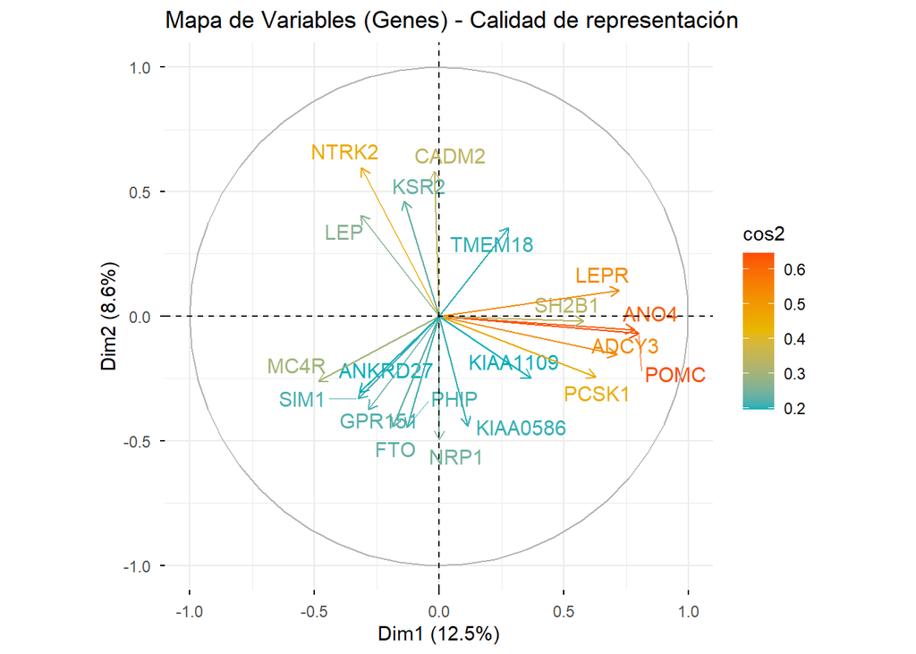

```r
# Gráfico de variables coloreadas por calidad de representación (cos2)
fviz_pca_var(pca_res,
             col.var = "cos2",
             gradient.cols = c("#00AFBB", "#E7B800", "#FC4E07"),
             select.var = list(cos2 = 20), #para poder visualizar mejor los resultados
             repel = TRUE, # Evita solapamiento de texto
             title = "Mapa de Variables (Genes) - Calidad de representación")
```

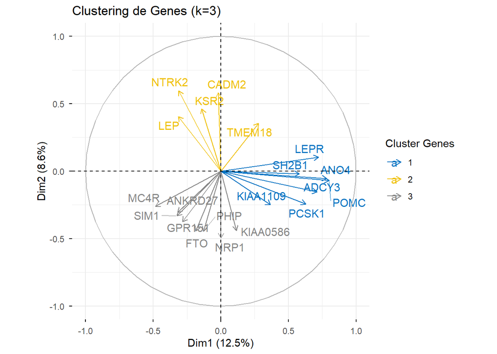

```r
# Clustering de variables (3 clusters)
var_coords <- get_pca_var(pca_res)$coord # Obtenemos coordenadas
km_vars <- kmeans(var_coords, centers = 3) # Calculamos k-means

# Visualizamos el clustering de variables
fviz_pca_var(pca_res,
             col.var = as.factor(km_vars$cluster), # Colorear por cluster
             palette = "jco",
             legend.title = "Cluster Genes",
             select.var = list(cos2 = 20),
             repel = TRUE,
             title = "Clustering de Genes (k=3)")
```

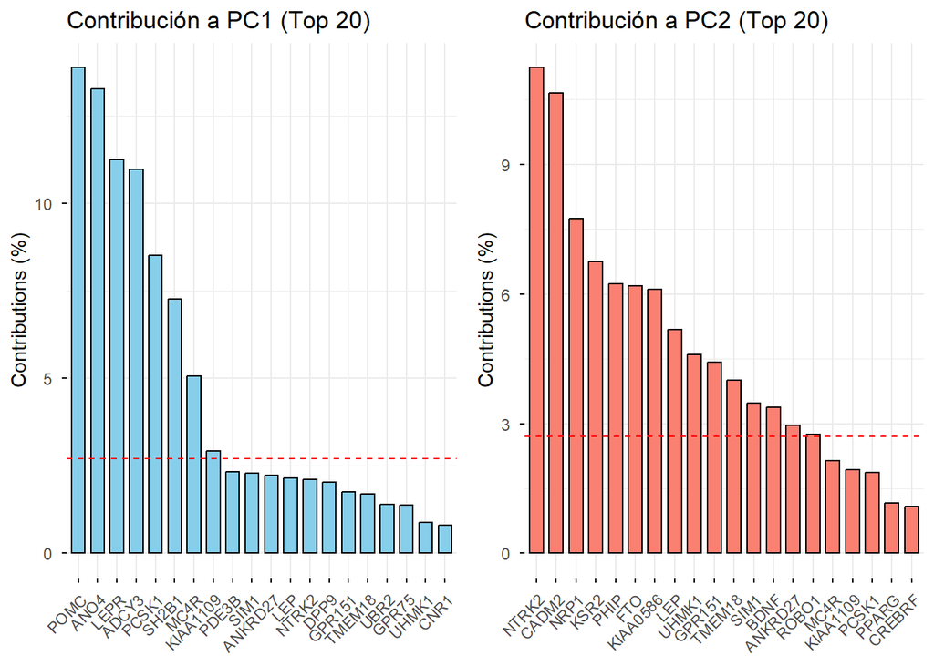

```r
# Contribuciones de las variables a los componentes

p1 <- fviz_contrib(pca_res, choice = "var", axes = 1, top = 20,
                   fill = "skyblue", color = "black") +
      ggtitle("Contribución a PC1 (Top 20)")
p2 <- fviz_contrib(pca_res, choice = "var", axes = 2, top = 20,
                   fill = "salmon", color = "black") +
      ggtitle("Contribución a PC2 (Top 20)")
grid.arrange(p1, p2, ncol = 2)
```

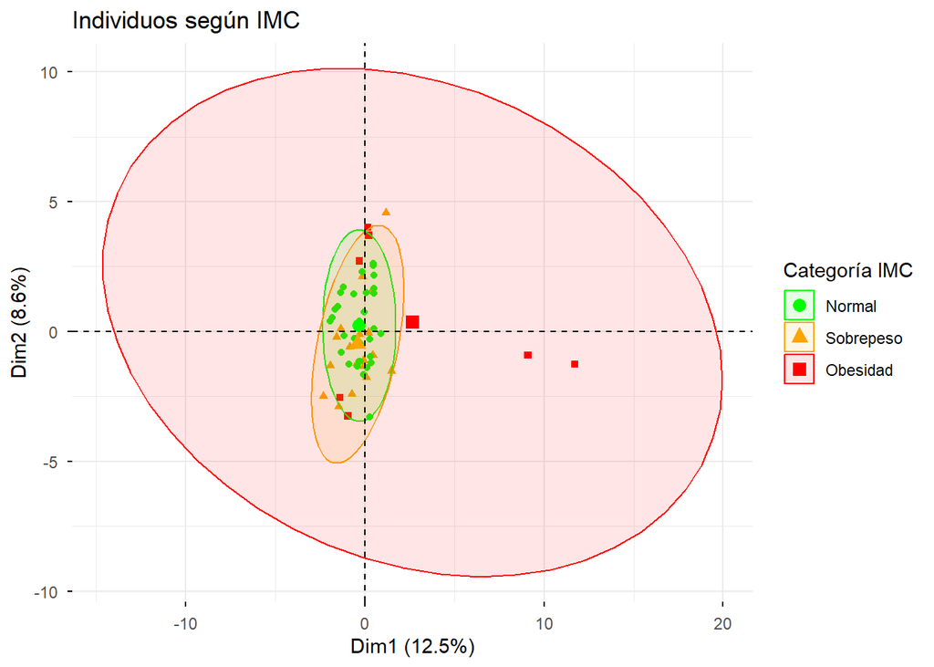

```r
# Gráfico de individuos coloreados por categoría de IMC
df_pca <- df_pca %>%
  mutate(IMC_cat = case_when(
    imc_kg_m2 < 25 ~ "Normal",
    imc_kg_m2 >= 25 & imc_kg_m2 < 30 ~ "Sobrepeso",
    imc_kg_m2 >= 30 ~ "Obesidad",
    TRUE ~ "Desconocido"
  ))

# Convertimos a factor para ordenar la leyenda correctamente
df_pca$IMC_cat <- factor(df_pca$IMC_cat, levels = c("Normal", "Sobrepeso", "Obesidad"))

# Graficamos los individuos
fviz_pca_ind(pca_res,
             geom.ind = "point", # Solo puntos para no saturar con texto
             col.ind = df_pca$IMC_cat, # Colorear por IMC
             palette = c("green", "orange", "red"), # Colores semáforo
             addEllipses = TRUE, # Elipses de confianza
             legend.title = "Categoría IMC",
             title = "Individuos según IMC")
```

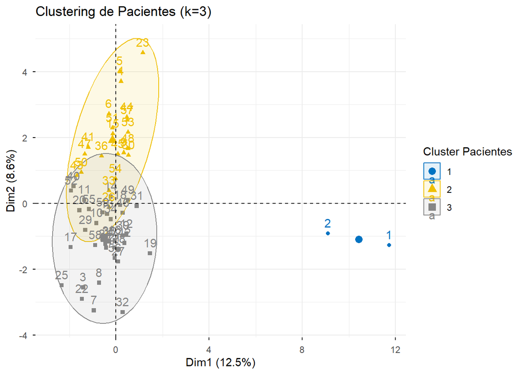

```r
# Clustering de individuos (3 clusters) basado en scores PCA
# Agrupamos a los pacientes según sus perfiles de expresión génica.
km_ind <- kmeans(pca_res$x[, 1:6], centers = 3, nstart = 25) # Usamos las primeras 6 componentes

# Añadimos el cluster al dataframe (útil para análisis posteriores)
df_pca$cluster_pca <- as.factor(km_ind$cluster)

# Visualizamos
fviz_pca_ind(pca_res,
             geom.ind = c("point", "text"),
             col.ind = df_pca$cluster_pca,
             palette = "jco",
             addEllipses = TRUE,
             legend.title = "Cluster Pacientes",
             title = "Clustering de Pacientes (k=3)")
```

## Interpretación de los resultados

### Contribución de los genes a las compontentes principales

En las gráficas mostradas se pudo observar qué genes contribuyen más dentro de cada componente principal. Más concretemente a las CP1 y CP2.

### PCA visualización de individuos (muestras)

Esta imagen muestra un gráfico de individuos del PCA, donde cada punto representa una muestra del estudio. La distribución se basa en los dos primeros componentes principales, que explican el 21.1% de la varianza total. La mayoría de los individuos se agrupan cerca del origen, aunque se observan algunos valores atípicos hacia la derecha del eje Dim1.

### Cluster plot de pacientes

Esta imagen muestra un gráfico de clusters (Cluster plot) que proyecta los resultados del agrupamiento K-means sobre los dos primeros componentes principales. Se identifican claramente tres grupos: el Cluster 1 (puntos azules) aparece aislado a la derecha, indicando un perfil de expresión muy distinto. Por el contrario, los Clusters 2 y 3 (triángulos amarillos y cuadrados grises) están solapados en el centro-izquierda, sugiriendo que, aunque el algoritmo detecta diferencias estadísticas, sus perfiles biológicos son bastante similares entre sí.

# Paso 5: Heatmap

Un mapa de calor es una técnica de visualización de datos que mide la magnitud de un fenómeno en colores en dos dimensiones. La variación del color puede ser por tono o intensidad, haciendo obvia la lectura del fenómeno sobre el espacio que se trata.

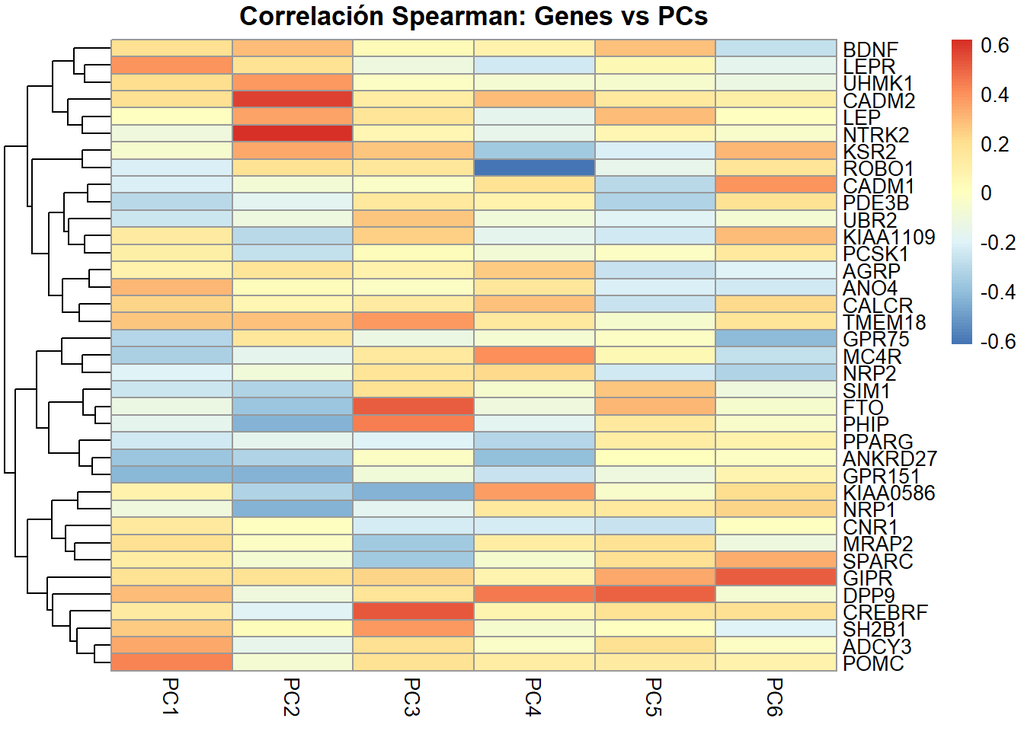

```r
# Correlación Spearman entre Genes y las primeras 6 PCs
cor_matrix <- cor(df_pca[, col_gen], df_pca[, c("PC1","PC2","PC3","PC4","PC5","PC6")],
                  method = "spearman")

# Dibujar Heatmap
pheatmap(cor_matrix,
         cluster_rows = TRUE,
         cluster_cols = FALSE,
         display_numbers = FALSE,
         main = "Correlación Spearman: Genes vs PCs")
```

Este mapa de calor (heatmap) muestra la correlación de Spearman entre los genes analizados y los seis primeros componentes principales (PCs). Los colores representan la fuerza de la relación: el rojo intenso indica una correlación positiva fuerte (cercana a 0.6), mientras que el azul señala una correlación negativa (cercana a -0.6).

Se observa que el PC2 está fuertemente definido por genes como *CADM2* y *NTRK2*, mientras que el PC6 muestra una relación positiva clara con *GIPR*. El dendrograma de la izquierda agrupa los genes con patrones de correlación similares, permitiendo identificar módulos funcionales. En conjunto, esta matriz ayuda a interpretar biológicamente qué procesos representa cada componente del PCA.

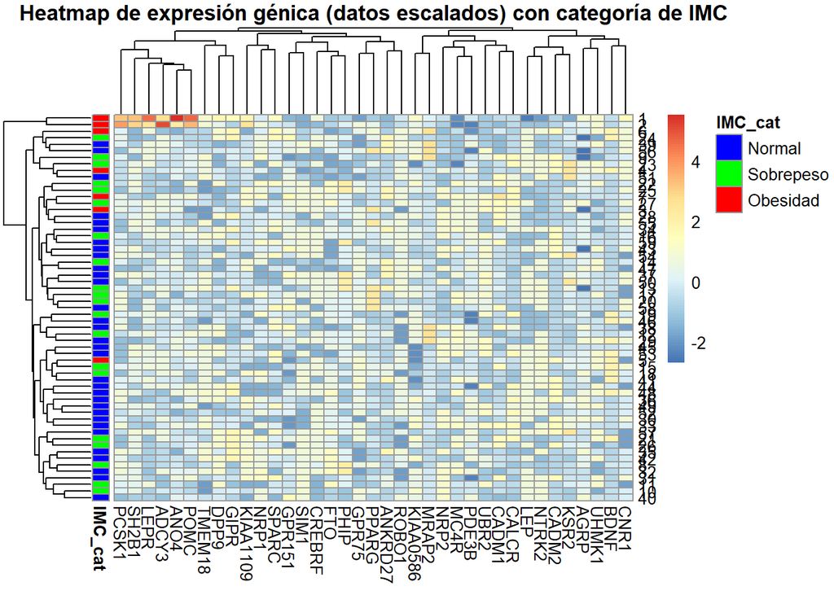

```r
# Heatmap de expresión génica (opcional)
# Escalado de la expresión génica por gen
genes_scaled <- as.matrix(scale(df_pca %>% select(ADCY3:UHMK1)))

# Asignar los nombres de fila para asegurar correspondencia
rownames(genes_scaled) <- rownames(df_pca)

# Crear dataframe de anotación con el IMC de los individuos
annotation_imc <- data.frame(IMC_cat = as.factor(df_pca$IMC_cat))

## Asignar los nombres de fila para asegurar correspondencia
rownames(annotation_imc) <- rownames(df_pca)

## Definir colores para la anotación categórica
annotation_colors <- list(
  IMC_cat = c(
    "Normal" = "blue",
    "Sobrepeso" = "green",
    "Obesidad" = "red"
  )
)

# Heatmap de expresión génica con anotación de IMC
pheatmap(
  genes_scaled,
  annotation_row = annotation_imc,
  annotation_colors = annotation_colors,
  show_rownames = TRUE,
  show_colnames = TRUE,
  clustering_distance_rows = "euclidean",
  clustering_distance_cols = "euclidean",
  clustering_method = "complete",
  main = "Heatmap de expresión génica (datos escalados) con categoría de IMC"
)
```

## Interpretación de los resultados

Los heatmaps construidos a partir de las correlaciones de Spearman entre las variables génicas y las primeras seis componentes principales, así como el heatmap de los datos de expresión génica escalados con anotación de la categoría de IMC, no revelaron patrones claros de asociación. De manera exploratoria, algunos genes como *PCSK1*, *SH2B1*, *LEPR*, *ADCY3*, *ANO4* y *POMC* parecen mostrar una mayor expresión en individuos con obesidad; no obstante, esta tendencia no da lugar a agrupamientos consistentes ni a una separación clara de los individuos según la categoría de IMC. En general, no se observaron agrupamientos definidos de genes asociados a componentes principales específicas ni una segregación evidente de los individuos en función del IMC. En conjunto, estos resultados sugieren que la variabilidad de la expresión génica se distribuye de forma compleja y no presenta asociaciones dominantes detectables mediante este enfoque exploratorio.

# Paso 6: Tabla descriptiva

```r
# Función para crear terciles para PC1, PC2 y PC3
make_terciles <- function(x){
  q <- quantile(x, probs = c(1/3, 2/3), na.rm = TRUE)
  cut(x, breaks = c(-Inf, q, Inf), labels = c("t1", "t2", "t3"))
}


# Función para calcular la mediana (P25, P75)
fmt_med_iqr <- function(x) {
  q <- quantile(x, probs = c(0.25, 0.5, 0.75), na.rm = TRUE)
  paste0(
    round(q[2], 2), " (",
    round(q[1], 2), ", ",
    round(q[3], 2), ")"
  )
}

# Crear terciles para PC1, PC2 y PC3 en el dataframe final
df_pca <- df_pca %>%
  mutate(
    PC1_t = make_terciles(PC1),
    PC2_t = make_terciles(PC2),
    PC3_t = make_terciles(PC3)
  )

# Definir los genes que queremos incluir (todos)
genes_df <- colnames(df_pca %>% select(ADCY3:UHMK1))

# Tabla de descriptivos por terciles PC1
desc_PC1 <- df_pca %>%
  select(PC1_t, all_of(genes_df)) %>%
  pivot_longer(-PC1_t, names_to = "Gen", values_to = "valor") %>%
  group_by(Gen, PC1_t) %>%
  summarise(
    estad = fmt_med_iqr(valor),
    .groups = "drop"
  ) %>%
  pivot_wider(names_from = PC1_t, values_from = estad)

pval_PC1 <- df_pca %>%
  select(PC1_t, all_of(genes_df)) %>%
  pivot_longer(-PC1_t, names_to = "Gen", values_to = "valor") %>%
  group_by(Gen) %>%
  summarise(
    p_PC1 = round(kruskal.test(valor ~ PC1_t)$p.value, 3),
    .groups = "drop"
  )

tabla_PC1 <- left_join(desc_PC1, pval_PC1, by = "Gen") %>%
  rename(
    T1_PC1 = t1,
    T2_PC1 = t2,
    T3_PC1 = t3,
    `Valor p_PC1` = p_PC1
  )

# Tabla de descriptivos por terciles PC2
desc_PC2 <- df_pca %>%
  select(PC2_t, all_of(genes_df)) %>%
  pivot_longer(-PC2_t, names_to = "Gen", values_to = "valor") %>%
  group_by(Gen, PC2_t) %>%
  summarise(
    estad = fmt_med_iqr(valor),
    .groups = "drop"
  ) %>%
  pivot_wider(names_from = PC2_t, values_from = estad)

pval_PC2 <- df_pca %>%
  select(PC2_t, all_of(genes_df)) %>%
  pivot_longer(-PC2_t, names_to = "Gen", values_to = "valor") %>%
  group_by(Gen) %>%
  summarise(
    p_PC2 = round(kruskal.test(valor ~ PC2_t)$p.value, 3),
    .groups = "drop"
  )

tabla_PC2 <- left_join(desc_PC2, pval_PC2, by = "Gen") %>%
  rename(
    T1_PC2 = t1,
    T2_PC2 = t2,
    T3_PC2 = t3,
    `Valor p_PC2` = p_PC2
  )

# Tabla de descriptivos por terciles PC3
desc_PC3 <- df_pca %>%
  select(PC3_t, all_of(genes_df)) %>%
  pivot_longer(-PC3_t, names_to = "Gen", values_to = "valor") %>%
  group_by(Gen, PC3_t) %>%
  summarise(
    estad = fmt_med_iqr(valor),
    .groups = "drop"
  ) %>%
  pivot_wider(names_from = PC3_t, values_from = estad)

pval_PC3 <- df_pca %>%
  select(PC3_t, all_of(genes_df)) %>%
  pivot_longer(-PC3_t, names_to = "Gen", values_to = "valor") %>%
  group_by(Gen) %>%
  summarise(
    p_PC3 = round(kruskal.test(valor ~ PC3_t)$p.value, 3),
    .groups = "drop"
  )

tabla_PC3 <- left_join(desc_PC3, pval_PC3, by = "Gen") %>%
  rename(
    T1_PC3 = t1,
    T2_PC3 = t2,
    T3_PC3 = t3,
    `Valor p_PC3` = p_PC3
  )

# Unir todas las componentes en una sola tabla
tabla_final <- tabla_PC1 %>%
  left_join(tabla_PC2, by = "Gen") %>%
  left_join(tabla_PC3, by = "Gen")

tabla_final <- tabla_final %>%
  mutate(
    `Valor p_PC1` = as.numeric(`Valor p_PC1`),
    `Valor p_PC2` = as.numeric(`Valor p_PC2`),
    `Valor p_PC3` = as.numeric(`Valor p_PC3`)
  )

# Formatar la tabla igual que el modelo
tabla_final %>%
  gt(rowname_col = "Gen") %>%
  tab_header(
    title = "Tabla descriptiva por terciles de las componentes principales"
  ) %>%
  tab_spanner(
    label = "Componente 1",
    columns = c(T1_PC1, T2_PC1, T3_PC1, `Valor p_PC1`)
  ) %>%
  tab_spanner(
    label = "Componente 2",
    columns = c(T1_PC2, T2_PC2, T3_PC2, `Valor p_PC2`)
  ) %>%
  tab_spanner(
    label = "Componente 3",
    columns = c(T1_PC3, T2_PC3, T3_PC3, `Valor p_PC3`)
  ) %>%
  cols_label(
    T1_PC1 = "T1", T2_PC1 = "T2", T3_PC1 = "T3", `Valor p_PC1` = "Valor p",
    T1_PC2 = "T1", T2_PC2 = "T2", T3_PC2 = "T3", `Valor p_PC2` = "Valor p",
    T1_PC3 = "T1", T2_PC3 = "T2", T3_PC3 = "T3", `Valor p_PC3` = "Valor p"
  ) %>%
  tab_style(
    style = cell_text(weight = "bold"),
    locations = list(
      cells_body(columns = `Valor p_PC1`, rows = `Valor p_PC1` < 0.05),
      cells_body(columns = `Valor p_PC2`, rows = `Valor p_PC2` < 0.05),
      cells_body(columns = `Valor p_PC3`, rows = `Valor p_PC3` < 0.05)
    )
  ) %>%
  tab_source_note(
    source_note = "Valores expresados como mediana (P25, P75). Test de Kruskal–Wallis. Los valores p < 0.05 se muestran en negrita."
  )
```

Tabla descriptiva por terciles de las componentes principales

|  | Componente 1 T1 | Componente 1 T2 | Componente 1 T3 | Componente 1 Valor p | Componente 2 T1 | Componente 2 T2 | Componente 2 T3 | Componente 2 Valor p | Componente 3 T1 | Componente 3 T2 | Componente 3 T3 | Componente 3 Valor p |
| --- | --- | --- | --- | --- | --- | --- | --- | --- | --- | --- | --- | --- |
| ADCY3 | -0.76 (-0.84, -0.54) | -0.54 (-0.76, -0.17) | -0.17 (-0.76, -0.17) | 0.016 | -0.18 (-0.76, -0.17) | -0.54 (-0.76, -0.17) | -0.54 (-0.76, -0.17) | 0.490 | -0.54 (-0.84, -0.45) | -0.54 (-0.76, -0.17) | -0.36 (-0.76, -0.17) | 0.351 |
| AGRP | 0.21 (-0.24, 0.43) | 0.21 (-0.02, 0.25) | 0.22 (-0.24, 0.66) | 0.707 | 0.21 (-0.24, 0.28) | 0.21 (0.21, 0.25) | 0.22 (0.1, 0.66) | 0.550 | 0.21 (-0.24, 0.41) | 0.25 (0.21, 0.51) | 0.21 (-0.24, 0.43) | 0.657 |
| ANKRD27 | 0.82 (-0.18, 0.82) | -0.18 (-0.35, 2.09) | -0.35 (-0.35, -0.18) | 0.046 | 0.32 (-0.18, 2.09) | 0.82 (-0.35, 0.82) | -0.35 (-0.35, -0.18) | 0.040 | -0.18 (-0.35, 1.14) | -0.18 (-0.35, 0.82) | -0.18 (-0.35, 2.09) | 0.719 |
| ANO4 | -0.51 (-0.69, -0.31) | -0.51 (-0.55, -0.31) | -0.31 (-0.55, -0.26) | 0.208 | -0.51 (-0.55, -0.31) | -0.31 (-0.51, -0.13) | -0.51 (-0.55, -0.31) | 0.117 | -0.51 (-0.55, -0.31) | -0.31 (-0.55, -0.24) | -0.51 (-0.55, -0.26) | 0.861 |
| BDNF | -0.77 (-0.89, -0.65) | -0.84 (-0.89, -0.65) | -0.67 (-0.84, 1.18) | 0.208 | -0.84 (-0.89, -0.68) | -0.7 (-0.86, -0.65) | -0.65 (-0.74, 1.18) | 0.154 | -0.77 (-0.89, -0.18) | -0.7 (-0.84, 1.17) | -0.77 (-0.85, -0.65) | 0.587 |
| CADM1 | -0.41 (-0.56, 1) | -0.05 (-0.56, 1) | -0.56 (-0.74, -0.41) | 0.029 | -0.23 (-0.56, 1) | -0.41 (-0.56, 0.47) | -0.41 (-0.56, -0.36) | 0.512 | -0.49 (-0.74, 1) | -0.41 (-0.56, 1) | -0.41 (-0.56, -0.05) | 0.507 |
| CADM2 | -0.67 (-0.72, -0.65) | -0.69 (-0.72, 1.21) | -0.65 (-0.7, 1.21) | 0.367 | -0.71 (-0.82, -0.69) | -0.69 (-0.72, 0.28) | 1.19 (-0.65, 1.21) | 0.000 | -0.65 (-0.72, -0.65) | -0.69 (-0.72, 1.16) | -0.65 (-0.7, 1.21) | 0.399 |
| CALCR | -0.35 (-1.02, 1.02) | -0.35 (-0.65, 1.02) | -0.21 (-0.35, 1.26) | 0.308 | -0.3 (-0.74, 1.26) | -0.35 (-0.65, 0.34) | 0.43 (-0.59, 1.26) | 0.337 | -0.35 (-0.74, 1.02) | -0.26 (-0.46, 1.5) | -0.26 (-0.65, 1.02) | 0.441 |
| CNR1 | -0.24 (-0.3, 0.69) | -0.24 (-1.12, 0.69) | -0.24 (-0.3, 0.69) | 0.667 | -0.24 (-0.3, 0.69) | -0.24 (-0.27, 0.69) | -0.24 (-0.71, 0.69) | 0.996 | 0.69 (-0.26, 0.69) | -0.24 (-0.3, 0.69) | -0.27 (-1.94, 0.69) | 0.151 |
| CREBRF | 0.38 (-1.35, 0.65) | 0.62 (-0.88, 0.73) | 0.73 (-1.35, 0.79) | 0.322 | 0.68 (0.5, 0.79) | 0.62 (-1.35, 0.73) | 0.1 (-1.35, 0.75) | 0.316 | -1.35 (-1.35, 0.65) | 0.62 (-1.35, 0.73) | 0.73 (0.62, 0.79) | 0.001 |
| DPP9 | -1.15 (-1.54, -0.24) | 0.75 (-0.26, 0.83) | -0.06 (-0.49, 0.83) | 0.025 | 0.29 (-0.49, 0.83) | -0.26 (-1.15, 0.44) | -0.26 (-1.15, 0.77) | 0.302 | -0.26 (-1.54, 0.77) | -0.26 (-1.15, 0.75) | 0.75 (-0.49, 0.83) | 0.369 |
| FTO | 0.6 (0.38, 0.93) | 0.6 (-0.28, 0.93) | 0.6 (-0.36, 0.93) | 0.756 | 0.93 (0.6, 1.68) | 0.6 (0.16, 0.93) | -0.3 (-1.45, 0.93) | 0.025 | 0.6 (-0.28, 0.6) | 0.6 (-1.06, 0.93) | 0.93 (0.84, 1.68) | 0.001 |
| GIPR | -0.39 (-0.76, 0.04) | 0.04 (-0.18, 1.65) | -0.18 (-0.6, 0.39) | 0.042 | -0.18 (-0.6, 1.47) | -0.18 (-1.02, 0.04) | -0.18 (-0.18, 0.04) | 0.402 | -0.18 (-0.6, 0.04) | -0.18 (-0.62, -0.07) | 0.04 (-0.28, 1.65) | 0.128 |
| GPR151 | 0.42 (0.05, 0.67) | 0.48 (-0.17, 0.67) | -0.17 (-1.19, 0.18) | 0.008 | 0.57 (0.39, 0.85) | -0.17 (-0.68, 0.42) | -0.17 (-0.42, 0.36) | 0.002 | 0.3 (-0.17, 0.67) | 0.12 (-0.68, 0.48) | 0.24 (-0.17, 0.53) | 0.481 |
| GPR75 | 0.58 (0.32, 0.71) | 0.32 (-1.14, 0.71) | 0.05 (-1.33, 0.46) | 0.090 | 0.32 (-1.33, 0.58) | 0.42 (-0.54, 0.71) | 0.37 (-0.25, 0.71) | 0.513 | 0.5 (-0.25, 0.61) | 0.42 (-0.54, 0.71) | 0.18 (-1.14, 0.61) | 0.498 |
| KIAA0586 | 0.51 (-0.47, 0.7) | 0.65 (0.02, 0.86) | 0.65 (-0.47, 0.86) | 0.822 | 0.75 (0.51, 0.86) | 0.65 (0.51, 0.75) | -0.47 (-1.26, 0.7) | 0.053 | 0.86 (0.62, 0.86) | 0.51 (-0.47, 0.75) | 0.25 (-0.47, 0.65) | 0.019 |
| KIAA1109 | -0.5 (-0.68, 0.34) | -0.5 (-0.59, 0.3) | -0.5 (-0.68, 0.45) | 0.830 | -0.09 (-0.5, 0.45) | -0.5 (-0.68, 0.3) | -0.59 (-1.58, -0.3) | 0.028 | -0.5 (-0.9, -0.5) | -0.5 (-0.68, 0.37) | -0.1 (-0.68, 0.45) | 0.250 |
| KSR2 | -0.23 (-0.47, 0.16) | -0.03 (-0.37, 0.61) | -0.23 (-0.77, 0.16) | 0.570 | -0.37 (-0.77, 0.02) | -0.23 (-0.3, -0.03) | 0.16 (-0.37, 1.99) | 0.041 | -0.3 (-0.77, -0.23) | -0.03 (-0.23, 0.38) | -0.03 (-0.37, 0.61) | 0.027 |
| LEP | 1.02 (-0.37, 1.1) | 1.02 (-0.67, 1.1) | 1.02 (0.69, 1.1) | 0.393 | -0.27 (-0.67, 1.04) | 1.02 (-0.59, 1.1) | 1.02 (1.02, 1.11) | 0.022 | 1.02 (-0.67, 1.04) | 1.02 (-0.27, 1.1) | 1.02 (-0.37, 1.11) | 0.525 |
| LEPR | -0.86 (-0.86, -0.2) | -0.2 (-0.86, -0.04) | -0.2 (-0.65, -0.04) | 0.057 | -0.76 (-0.9, -0.17) | -0.2 (-0.86, -0.12) | -0.2 (-0.86, -0.04) | 0.399 | -0.2 (-0.86, -0.04) | -0.65 (-0.86, -0.04) | -0.42 (-0.86, -0.2) | 0.778 |
| MC4R | 0.52 (-0.02, 1.23) | 0.14 (-0.02, 0.9) | -0.48 (-0.48, 0.33) | 0.039 | 0.9 (-0.13, 0.99) | 0.14 (-0.02, 1.23) | 0.14 (-0.13, 0.9) | 0.771 | -0.02 (-0.48, 0.9) | 0.14 (-0.02, 1.23) | 0.52 (-0.02, 0.98) | 0.443 |
| MRAP2 | -0.24 (-0.53, -0.22) | -0.24 (-0.53, -0.18) | -0.24 (-0.33, -0.12) | 0.246 | -0.24 (-0.53, -0.18) | -0.24 (-0.38, -0.21) | -0.28 (-0.53, -0.18) | 0.884 | -0.18 (-0.31, 2.39) | -0.24 (-0.44, -0.24) | -0.29 (-0.53, -0.18) | 0.070 |
| NRP1 | 0.69 (-0.03, 0.78) | -0.01 (-0.01, 0.69) | -0.01 (-1.64, 0.91) | 0.674 | 0.73 (-0.01, 1.29) | 0.69 (-0.01, 0.78) | -1.24 (-1.64, 0.33) | 0.009 | 0.34 (-0.01, 0.78) | 0.21 (-0.86, 1.03) | -0.01 (-1.34, 0.71) | 0.454 |
| NRP2 | 0.88 (-1.15, 0.94) | -0.6 (-1.41, 0.94) | -0.88 (-1.15, 0.46) | 0.326 | -0.6 (-1.28, 0.94) | -0.6 (-1.15, 0.88) | -0.09 (-1.28, 0.88) | 0.914 | -0.88 (-1.28, 0.88) | -0.6 (-1.15, 0.88) | 0.75 (-1.15, 0.9) | 0.399 |
| NTRK2 | 1.09 (-0.37, 1.09) | -0.37 (-0.5, 1.21) | 1.09 (-0.63, 1.1) | 0.943 | -0.37 (-0.63, -0.37) | 1.09 (0.26, 1.1) | 1.1 (1.09, 1.31) | 0.000 | 1.09 (-0.43, 1.1) | 1.09 (0.36, 1.09) | -0.37 (-0.63, 1.31) | 0.907 |
| PCSK1 | -0.47 (-1.22, -0.19) | -0.47 (-0.98, -0.17) | -0.47 (-0.75, -0.3) | 0.871 | -0.3 (-0.54, -0.03) | -0.47 (-0.98, -0.3) | -0.61 (-1.22, -0.47) | 0.050 | -0.47 (-0.87, -0.3) | -0.47 (-0.75, -0.27) | -0.47 (-1.22, -0.03) | 0.956 |
| PDE3B | 0.91 (0.34, 0.93) | 0.34 (0.23, 0.91) | 0.23 (-0.2, 0.91) | 0.089 | 0.91 (0.23, 0.93) | 0.91 (0.23, 0.93) | 0.34 (0.23, 0.91) | 0.448 | 0.62 (-0.13, 0.92) | 0.91 (0.23, 0.91) | 0.34 (0.23, 0.92) | 0.900 |
| PHIP | 0.12 (-0.88, 0.6) | 0.11 (-0.73, 0.13) | 0.09 (-0.08, 0.11) | 0.518 | 0.13 (0.09, 0.6) | 0.09 (-0.39, 0.12) | -0.25 (-0.88, 0.11) | 0.019 | 0.09 (-0.88, 0.11) | 0.09 (-0.88, 0.12) | 0.13 (0.1, 2.01) | 0.002 |
| POMC | -0.58 (-0.73, -0.34) | -0.34 (-0.58, -0.24) | -0.24 (-0.58, 0.07) | 0.010 | -0.34 (-0.58, -0.24) | -0.34 (-0.73, 0.07) | -0.34 (-0.58, -0.24) | 0.864 | -0.58 (-0.61, -0.24) | -0.34 (-0.73, -0.09) | -0.29 (-0.58, -0.17) | 0.283 |
| PPARG | -0.42 (-0.7, 0.8) | -0.42 (-0.69, 0.11) | -0.96 (-1.08, -0.42) | 0.064 | -0.42 (-0.96, 0.18) | -0.42 (-0.69, 0.11) | -0.69 (-1.08, -0.29) | 0.258 | -0.42 (-0.96, 0.23) | -0.42 (-0.96, 0.11) | -0.42 (-0.99, -0.29) | 0.510 |
| ROBO1 | 0.61 (-0.53, 0.66) | 0.61 (0.23, 0.77) | 0.23 (-0.94, 0.61) | 0.158 | 0.42 (-0.94, 0.64) | -0.53 (-2.16, 0.76) | 0.61 (0.23, 0.62) | 0.401 | 0.42 (-0.94, 0.75) | 0.23 (-0.53, 0.62) | 0.61 (0.23, 0.76) | 0.527 |
| SH2B1 | -0.34 (-1.01, -0.12) | -0.21 (-0.93, -0.12) | -0.17 (-0.93, -0.06) | 0.317 | -0.21 (-0.93, -0.12) | -0.21 (-0.93, -0.12) | -0.21 (-0.93, -0.06) | 0.917 | -1.1 (-1.28, -0.21) | -0.12 (-0.21, 0.1) | -0.17 (-0.93, -0.12) | 0.001 |
| SIM1 | 1.21 (0.73, 1.22) | 1.03 (-0.17, 1.21) | 0.43 (-0.52, 1.21) | 0.144 | 1.21 (0.73, 1.21) | 1.03 (-0.17, 1.21) | 0.43 (-0.53, 1.21) | 0.155 | -0.17 (-0.17, 1.21) | 1.03 (-0.52, 1.21) | 1.21 (1.03, 1.21) | 0.310 |
| SPARC | -0.12 (-0.24, -0.04) | -0.04 (-1.25, 1.08) | -0.04 (-0.46, 0.88) | 0.687 | -0.04 (-0.24, 1.08) | -0.04 (-0.12, 0.82) | -0.28 (-1.25, 0.82) | 0.195 | -0.04 (-0.08, 0.88) | -0.04 (-0.19, 0.82) | -0.28 (-1.25, 0.17) | 0.050 |
| TMEM18 | -0.34 (-0.98, 0) | 0.72 (-0.34, 1) | 0.63 (-0.34, 0.83) | 0.030 | -0.34 (-0.66, 0.88) | -0.24 (-0.66, 0.77) | 0.72 (-0.27, 0.83) | 0.179 | -0.66 (-0.66, 0.65) | 0.63 (-0.66, 0.72) | 0.83 (-0.27, 1) | 0.014 |
| UBR2 | 0.68 (-0.71, 1.33) | 0.68 (-0.72, 1.41) | -0.71 (-0.74, 0.68) | 0.116 | 0.68 (-0.71, 1.33) | 0.68 (-0.72, 1.01) | -0.71 (-0.74, 1.33) | 0.664 | -0.71 (-0.74, 0.68) | 0.68 (-0.71, 1.33) | 0.68 (-0.71, 1.5) | 0.190 |
| UHMK1 | -0.63 (-0.75, 0.65) | -0.75 (-1.35, -0.63) | 0.67 (-0.63, 0.71) | 0.022 | -0.75 (-1.95, -0.32) | -0.63 (-0.75, 0.71) | 0.66 (-0.63, 0.71) | 0.032 | -0.63 (-1.05, 0.71) | 0.66 (-0.75, 0.71) | -0.69 (-1.05, 0.66) | 0.309 |

Valores expresados como mediana (P25, P75). Test de Kruskal–Wallis. Los valores p < 0.05 se muestran en negrita.

## Interpretación de los resultados

Se realizó la tabla de descriptivos de los valores de expresión génica originales estratificadas por terciles de las tres primeras componentes principales (PC1, PC2 y PC3). Dado que las variables no presentaban distribución normal, los resultados se expresaron como mediana y rango intercuartílico (P25–P75), y las comparaciones entre terciles se realizaron mediante el test no paramétrico de Kruskal–Wallis.

Se observaron diferencias estadísticamente significativas en la expresión de varios genes a lo largo de los terciles de la **PC1**, concretamente para *ADCY3*, *ANKRD27*, *CADM1*, *DPP9*, *GIPR*, *GPR151*, *MC4R*, *POMC*, *TMEM18* y *UHMK1*. En el caso de la **PC2**, los genes que mostraron diferencias significativas entre terciles fueron *ANKRD27*, *CADM2*, *FTO*, *GPR151*, *KIAA1109*, *KSR2*, *LEP*, *NRP1*, *NTRK2*, *PHIP* y *UHMK1*. Por último, para la **PC3** se identificaron diferencias significativas en los genes *CREBRF*, *FTO*, *KIAA0586*, *KSR2*, *PHIP*, *SH2B1* y *TMEM18*.

# Paso 7: Regresión

```r
# Preparación de datos
df_model <- df_pca |>
  # Asegúrate de que las columnas existen y coinciden con tus datos
  filter(!is.na(imc_kg_m2), !is.na(edad_anios), !is.na(sexo)) |>
  mutate(
    # Variable dependiente: Obesidad (IMC >= 30)
    obesidad_bin = if_else(imc_kg_m2 >= 30, 1, 0),

    # Aseguramos niveles de referencia t1
    PC1_t = relevel(factor(PC1_t), ref = "t1"),
    PC2_t = relevel(factor(PC2_t), ref = "t1"),
    PC3_t = relevel(factor(PC3_t), ref = "t1"),
    sexo  = factor(sexo)
  )

#  Ajuste del Modelo Logístico (Para la Tabla)
m3 <- glm(obesidad_bin ~ PC1_t + PC2_t + PC3_t + edad_anios + sexo,
          data = df_model, family = binomial())

# Función para filas de Terciles (PC)
make_tercile_row <- function(model, pc_term, label) {
  td <- broom::tidy(model, exponentiate = TRUE, conf.int = TRUE)

  # Busca los términos específicos para t2 y t3
  t2 <- td |> filter(term == paste0(pc_term, "t2"))
  t3 <- td |> filter(term == paste0(pc_term, "t3"))

  tibble(
    Variable = label,
    T1_OR = "1 (Ref.)", T1_p = "---",

    T2_OR = if (nrow(t2)==1) sprintf("%.2f (%.2f a %.2f)", t2$estimate, t2$conf.low, t2$conf.high) else "-",
    T2_p  = if (nrow(t2)==1) formatC(t2$p.value, format = "f", digits = 3) else "-",

    T3_OR = if (nrow(t3)==1) sprintf("%.2f (%.2f a %.2f)", t3$estimate, t3$conf.low, t3$conf.high) else "-",
    T3_p  = if (nrow(t3)==1) formatC(t3$p.value, format = "f", digits = 3) else "-"
  )
}

# Función para Covariables (Edad, Sexo)
make_cov_rows <- function(model) {
  broom::tidy(model, exponentiate = TRUE, conf.int = TRUE) |>
    # Quitamos componentes principales y el Intercepto
    filter(!stringr::str_detect(term, "^PC[123]_t"),
           term != "(Intercept)") |>

    # Renombramos las variables
    mutate(
      term_limpio = case_when(
        term == "edad_anios" ~ "Edad (Años)",
        stringr::str_detect(term, "sexo") ~ "Sexo",
        TRUE ~ term
      ),

      OR_IC = sprintf("%.2f (%.2f a %.2f)", estimate, conf.low, conf.high),
      p_chr = formatC(p.value, format = "f", digits = 3)
    ) |>

    # Construimos la fila final
    transmute(
      Variable = term_limpio,
      T1_OR = OR_IC, T1_p = p_chr,
      T2_OR = "",    T2_p = "",
      T3_OR = "",    T3_p = ""
    )
}

# Construcción de la tabla
tab_pc1_reg <- make_tercile_row(m3, "PC1_t", "Terciles componente 1")
tab_pc2_reg <- make_tercile_row(m3, "PC2_t", "Terciles componente 2")
tab_pc3_reg <- make_tercile_row(m3, "PC3_t", "Terciles componente 3")
ajustes     <- make_cov_rows(m3)

tabla_regresion <- bind_rows(tab_pc1_reg, tab_pc2_reg, tab_pc3_reg, ajustes)

# Renderizado con GT
tab_reg_gt <- tabla_regresion |>
  gt() |>
  tab_header(title = "Tabla de regresión logística (Outcome: Obesidad IMC ≥ 30)") |>
  tab_spanner(label = "T1 (Bajo)", columns = c(T1_OR, T1_p)) |>
  tab_spanner(label = "T2 (Medio)", columns = c(T2_OR, T2_p)) |>
  tab_spanner(label = "T3 (Alto)", columns = c(T3_OR, T3_p)) |>
  cols_label(
    Variable = "",
    T1_OR = "OR (IC 95%)", T1_p = "P valor",
    T2_OR = "OR (IC 95%)", T2_p = "P valor",
    T3_OR = "OR (IC 95%)", T3_p = "P valor"
  ) |>
  tab_source_note("Modelo multivariante ajustado por edad y sexo.") |>
  cols_align(align = "center", columns = -Variable)

tab_reg_gt
```

Tabla de regresión logística (Outcome: Obesidad IMC ≥ 30)

|  | T1 (Bajo) OR (IC 95%) | T1 (Bajo) P valor | T2 (Medio) OR (IC 95%) | T2 (Medio) P valor | T3 (Alto) OR (IC 95%) | T3 (Alto) P valor |
| --- | --- | --- | --- | --- | --- | --- |
| Terciles componente 1 | 1 (Ref.) | --- | 0.58 (0.02 a 7.48) | 0.680 | 3.36 (0.46 a 35.81) | 0.258 |
| Terciles componente 2 | 1 (Ref.) | --- | 0.17 (0.01 a 2.09) | 0.205 | 0.80 (0.05 a 8.54) | 0.855 |
| Terciles componente 3 | 1 (Ref.) | --- | 4.35 (0.45 a 102.16) | 0.247 | 1.02 (0.06 a 27.15) | 0.986 |
| Edad (Años) | 1.02 (0.97 a 1.07) | 0.378 |  |  |  |  |
| Sexo | 1.28 (0.07 a 21.01) | 0.858 |  |  |  |  |

Modelo multivariante ajustado por edad y sexo.